# ModelBuilding

Marieke

October 27, 2016

## Introduction

This code is built using the online github documentation of the caret package of Max Kuhn, [The caret Package](http://topepo.github.io/caret/index.html). Also the book [Applied predictive modeling by Max Kuhn and Kjel Johnson, 2013](http://www.amazon.com/Applied-Predictive-Modeling-Max-Kuhn/dp/1461468485/ref=pd_bxgy_b_img_z) was used. [Previous studies](http://www.sciencedirect.com/science/article/pii/S2211675315000482) also used the same the same approache.

Here we use the caret package to built machine learning models to create a solar irradiance model. As input we use satellite data and ground based observations. We found that there is a small sinus yearly trend in the differences between the two products. Therefore also the day of the year is included as an additional explanatory variable for the differences between the two products.

## Loading library

```r
library(data.table)
library(lubridate)
library(mgcv)
library(adehabitat)
library(automap)
library(caret)
library(doParallel)
library(kernlab)
library(reshape)
library(raster)
library(rgdal)
library(SDMTools)
pro=CRS("+init=epsg:28992")
save_dir<-"/nobackup/users/dirksen/radiation/Rdata/MLmodels/finalModels/"
```

## Comparing the 2 products

To compare the satellite data with the point measurements the R function over is used. The data was stored in the file “sat_over_obs.csv”. Using the data.table package and mgcv package we made a summary of the results. We find that the differences between the two products are small. There is a yearly pattern in the data: during winter months the satellite derived products has slightly higher values (max around 3W/m2) while in summer the opposit is true.

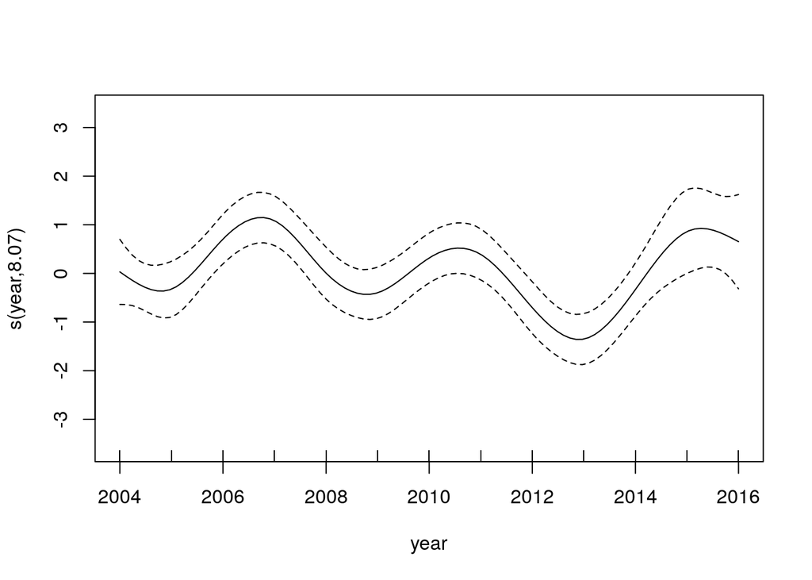

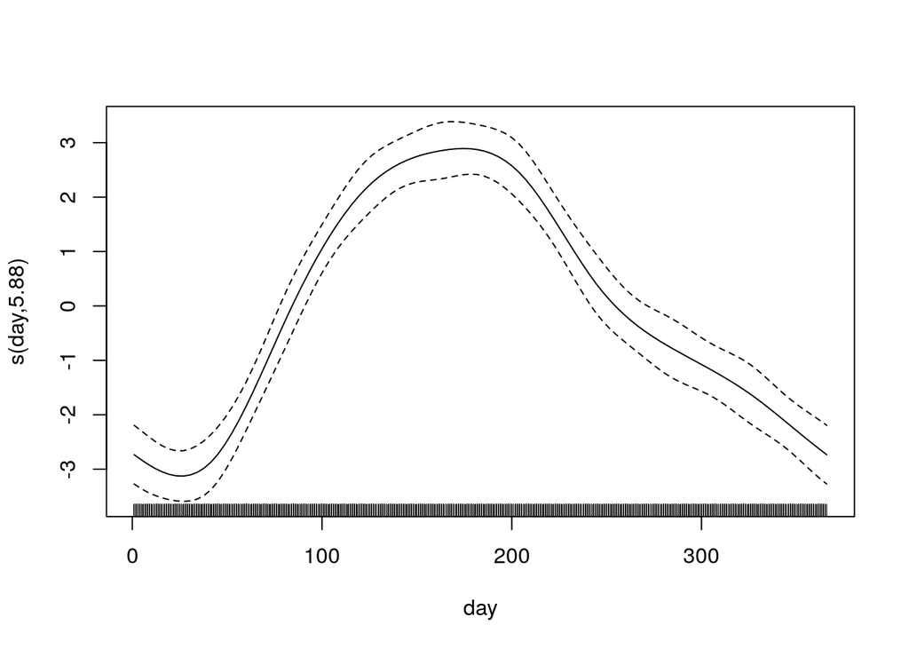

```r
obs.df <- fread("Rdata/sat_over_obs.csv")
names(obs.df) <- c("IT_DATETIME","DS_CODE","Q","x","y","SAT","DIFF")
obs.df$IT_DATETIME <- as.Date(obs.df$IT_DATETIME)
obs.df$day <- yday(obs.df$IT_DATETIME)
obs.df$month <- month(obs.df$IT_DATETIME)

setkey(obs.df, day)
obs.df <- obs.df[complete.cases(obs.df),]
# summary_by_stationday <-data.obs[, mean(DIFF), by = .(year = year(IT_DATETIME),day=day,DS_CODE)]
summary_by_year_day <- obs.df[, mean(DIFF), by = .(year = year(IT_DATETIME), day)]
summary_by_year_month <- obs.df[, mean(DIFF), by = .(year = year(IT_DATETIME), month)]


#fitting routines
fit1 <- gam(V1 ~ s(year) + s(day, bs = "cc"), data = summary_by_year_day)
plot(fit1)
```

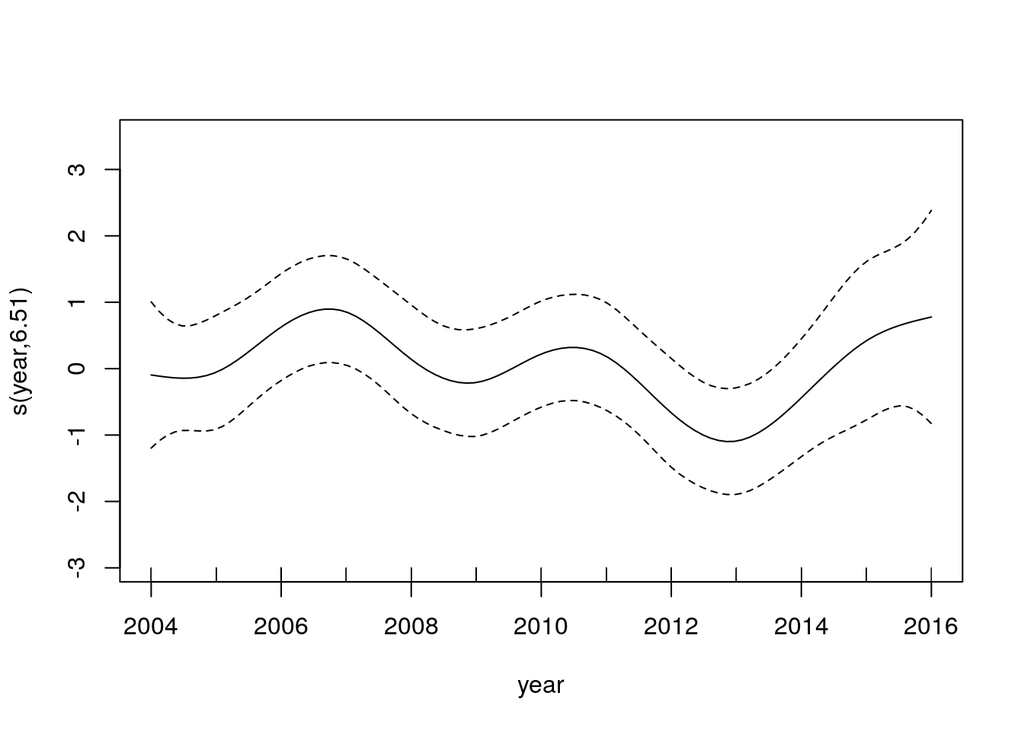

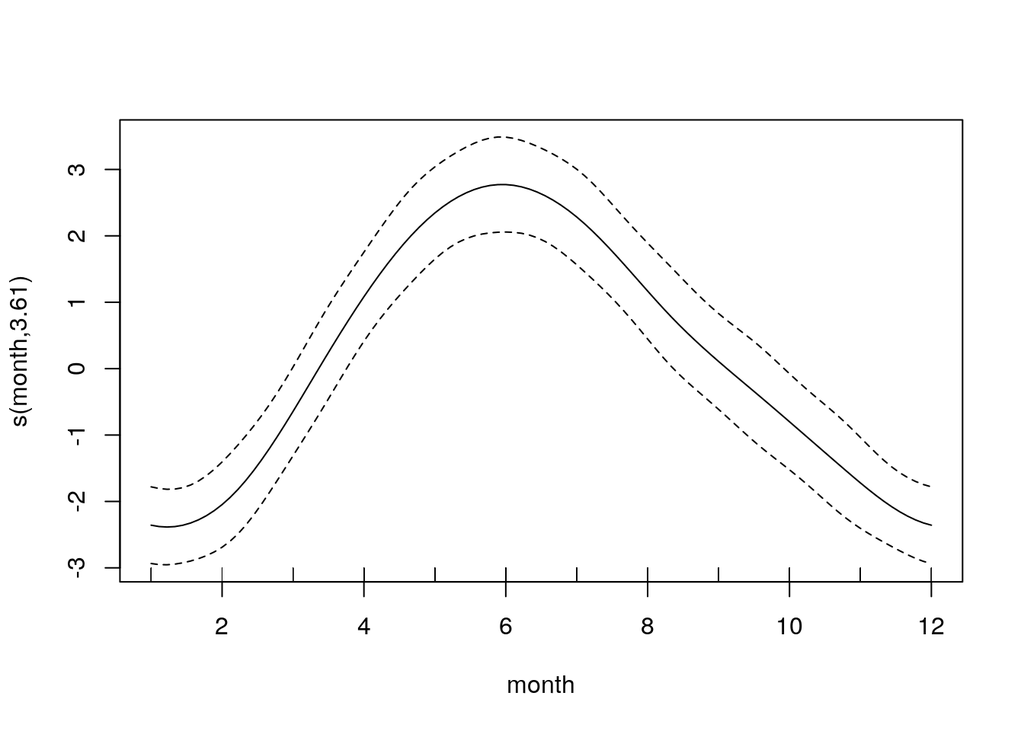

```r
fit2 <- gam(V1 ~ s(year) + s(month, bs = "cc"), data = summary_by_year_month)
plot(fit2)
```

## Training and test set

```r
set.seed(999)
trainIndex<-createDataPartition(obs.df$Q,p=0.80,list=FALSE)
train<-obs.df[trainIndex,]
setkey(train, day)
test<-obs.df[-trainIndex,]
setkey(test, day)
```

## Parallel cluster

The caret models allow parallel computations. In the trainControl function it states: allowParallel=TRUE. So, therefore we only need to make a cluster with the doParallel packages using 2 lines of code.

```r
cl<-makeCluster(6)
registerDoParallel(cl)
```

## Building Machine Learning Algorithms

### Train control

> For more background information: * The github post on [model training and tuning](http://topepo.github.io/caret/model-training-and-tuning.html). * A list with all the available regression models can be found [online](http://topepo.github.io/caret/available-models.html), search for regression. * [parallel](http://stackoverflow.com/questions/13403427/fully-reproducible-parallel-models-using-caret)

```r
set.seed(123)
seeds <- vector(mode = "list", length = 11)#length is = (n_repeats*nresampling)+1
for(i in 1:30) seeds[[i]] <- sample.int(n=1000, 30) #(30 is the number of tuning parameter, mtry for rf, here equal to ncol(iris)-2)
seeds[[31]]<-sample.int(1000, 1)


indx <- createFolds(train , returnTrain = TRUE)
# control<-trainControl(method="repeatedcv",repeats=3,index=createFolds(obs.df$Q),seeds=seeds)
control<-trainControl(method = "repeatedcv",
                      repeats = 3,
                      number = 10,
                      index = train,
                      seeds = seeds)
length <- 15 #for the tuneLength of the models

controlObject <- trainControl(method = "repeatedcv",
                              repeats = 3,
                              number = 10,
                              index = createFolds(train$Q),
                              seeds = seeds)
```

### Train models

The best way of saving your models is by using the saveRDS command. This compressed data format can be read into R very fast, compared to the older commands in R you’re also able to provide your loaded data with a name (thus not only the name you used to save the data). The stored models will be used to predict radiation for a larger area where no measurements are available.

One should note that not the “normal” train function is used but caret::train. The addition of caret:: alows to predict spatial data. For spatial predictions we then use a line like: raster::predict(model=final.model,object=satellite.grid)

#### Linear Models

```r
m1.lm <- caret::train(Q ~ SAT + day,
                      data = train,
                      method = "lm",
                      preProcess = c("center","scale","BoxCox"),
                      tuneLength = length,
                      trControl = controlObject)
# saveRDS(m1.lm,file=paste0(save_dir,"lm.rds"))

m2.glm <- caret::train(Q ~ SAT + day,
                       data = train,
                       method = "glm",
                       preProcess = c("center","scale","BoxCox"),
                       tuneLength = length,
                       trControl = controlObject)
# saveRDS(m2.glm,file=paste0(save_dir,"glm.rds"))

# m3.gaussprLinear <- caret::train(Q ~ SAT + day,
#                                  data = obs.df,
#                                  method = "gaussprLinear",
#                                  preProcess = c("center","scale","BoxCox"),
#                                  verbose = FALSE,
#                                  tuneLength = length,
#                                  trControl = controlObject)
# saveRDS(m3.gaussprlinear,file=paste0(save_dir,"gaussprlinear.rds"))
```

#### Support Vector Machines

```r
sigmaRangeReduced<-sigest(as.matrix(obs.df$Q))[1]
svmRadialRGridReduced<-expand.grid(.sigma=sigmaRangeReduced,.C=2^(seq(-4,4)))

m4.svmRadial<-caret::train(Q ~ SAT + day,
                           data = train,
                           method = "svmRadial",
                           preProcess = c("center","scale","BoxCox"),
                           verbose = FALSE,
                           tuneLength = length,
                           trControl = controlObject,
                           tuneGrid = svmRadialRGridReduced)
# saveRDS(m4.svmRadial,file=paste0(save_dir,"svmRadial.rds"))

svmLinearRGridReduced<-expand.grid(C=2^(seq(-4,4)))

m5.svmLinear<-caret::train(Q ~ SAT + day,
                           data = train,
                           method = "svmLinear",
                           preProcess = c("center","scale","BoxCox"),
                           verbose = FALSE,
                           tuneLength = length,
                           trControl = controlObject,
                           tuneGrid = svmLinearRGridReduced)
# saveRDS(m5.svmLinear,file=paste0(save_dir,"svmLinear.rds"))
```

#### Tree models

```r
m7.cubist <- caret::train(Q ~ SAT + day,
                          data = train,
                          method = "cubist",
                          preProcess = c("center","scale","BoxCox"),
                          verbose = FALSE,
                          tuneLength = length,
                          trControl = controlObject)
# saveRDS(m7.cubist,file=paste0(save_dir,"cubist.rds"))

earthGridReduced <- data.frame(.degree = 1,
                               .nprune = 2:25)

m10.earth <- caret::train(Q ~ SAT + day,
                          data = train,
                          method = "earth",
                          preProcess = c("center","scale","BoxCox"),
                          tuneLength = length,
                          trControl = controlObject,
                          tuneGrid = earthGridReduced)
# saveRDS(m10.earth,file=paste0(save_dir,"earth.rds"))

#Long runtime for the following tree based models
# m6.treebag <- caret::train(Q~SAT+day,data=obs.df,method="treebag",preProcess=c("center","scale","BoxCox"),verbose=FALSE,tuneLength=length,trControl=control)
# saveRDS(m6.treebag,file=paste0(save_dir,"treebag.rds"))
# ctreeGridReduced<-expand.grid(mincriterion=seq(from=0.1,to=0.5,by=0.1))
# m8.ctree <- caret::train(Q~SAT+day,data=obs.df,method="ctree",preProcess=c("center","scale","BoxCox"),tuneLength=length,trControl=control,tuneGrid=ctreeGridReduced)
# saveRDS(m8.ctree,file=paste0(save_dir,"ctree.rds"))
```

#### K-nearest neighbors

```r
knnGridReduced<-expand.grid(.k=3:15)

m9.knn <- caret::train(Q ~ SAT + day,
                       data = train,
                       method = "knn",
                       preProcess = c("center","scale","BoxCox"),
                       verbose = FALSE,
                       tuneLength = length,
                       trControl = controlObject,
                       tuneGrid = knnGridReduced)
# saveRDS(m9.knn,file=paste0(save_dir,"knn.rds"))
```

#### Boosting

```r
gbmGridReduced<-expand.grid(.shrinkage = c(0.1),
                            .n.trees = 3:5,
                            .interaction.depth = 4:6,
                            .n.minobsinnode = 3:5)

m11.gbm <- caret::train(Q ~ SAT + day,
                        data = train,
                        method = "gbm",
                        preProcess = c("center","scale","BoxCox"),
                        tuneLength = length,
                        trControl = controlObject,
                        tuneGrid = gbmGridReduced,
                        verbose = FALSE)
# saveRDS(m11.gbm,file=paste0(save_dir,"gbm.rds"))
```

#### Neural networks

```r
#adapted after page 366 Kuhn 2013


nnetGrid <- expand.grid(.size = 1:10, .decay = c(0.01 , .1))
maxSize <- max(nnetGrid$.size)
numWts <- 1*(maxSize * (length(obs.df) + 1) + maxSize + 1)

m13.nnet <- caret::train(Q ~ SAT + day,
                         data = train,
                         method = "nnet",
                         #metric = "ROC",
                         preProcess = c("center","scale","spatialSign"),
                         tuneGrid = nnetGrid,
                         trace = FALSE,
                         maxit = 2000 ,
                         MaxNWts = numWts,
                         linout = TRUE,            #For regression = TRUE
                         trControl = controlObject)
# saveRDS(m13.nnet,file=paste0(save_dir,"nnet.rds"))
```

### The Results

The caret package provides some easy to use commands for summarizing your results. With resamples we list all the models and are able to plot them with bwplot. Also, model difference can be seen with one line of code.

```r
results<-resamples(list(lm = m1.lm,
                        glm = m2.glm,
                        #gaussprLinear=m3.gaussprLinear,
                        svmRadial=m4.svmRadial,
                        svmLinear=m5.svmLinear,
                        #treebag=m6.treebag,
                        cubist = m7.cubist,
                        #ctreer=m8.ctree,
                        knn = m9.knn,
                        earth = m10.earth,
                        gbm = m11.gbm,
                        #fuzzy = m12.fuzzy,
                        nnet = m13.nnet))
summary(results)
```

```
##
## Call:
## summary.resamples(object = results)
##
## Models: lm, glm, svmRadial, svmLinear, cubist, knn, earth, gbm, nnet
## Number of resamples: 10
##
## RMSE
##            Min. 1st Qu. Median  Mean 3rd Qu.  Max. NA's
## lm        26.83   26.84  26.85 26.85   26.85 26.88    0
## glm       26.83   26.84  26.85 26.85   26.85 26.88    0
## svmRadial 11.08   11.09  11.10 11.11   11.12 11.14    0
## svmLinear 27.25   27.30  27.32 27.31   27.33 27.34    0
## cubist    11.12   11.13  11.15 11.16   11.18 11.22    0
## knn       11.28   11.31  11.31 11.31   11.33 11.34    0
## earth     11.32   11.35  11.37 11.37   11.38 11.42    0
## gbm       54.99   55.07  55.11 55.10   55.14 55.27    0
## nnet      27.19   27.22  27.24 27.25   27.28 27.33    0
##
## Rsquared
##             Min. 1st Qu. Median   Mean 3rd Qu.   Max. NA's
## lm        0.9124  0.9125 0.9126 0.9126  0.9126 0.9127    0
## glm       0.9124  0.9125 0.9126 0.9126  0.9126 0.9127    0
## svmRadial 0.9850  0.9850 0.9851 0.9850  0.9851 0.9851    0
## svmLinear 0.9124  0.9125 0.9126 0.9126  0.9126 0.9127    0
## cubist    0.9847  0.9849 0.9849 0.9849  0.9850 0.9850    0
## knn       0.9844  0.9844 0.9845 0.9845  0.9845 0.9846    0
## earth     0.9842  0.9843 0.9843 0.9843  0.9844 0.9844    0
## gbm       0.9768  0.9776 0.9783 0.9782  0.9787 0.9790    0
## nnet      0.9093  0.9097 0.9100 0.9099  0.9101 0.9103    0
```

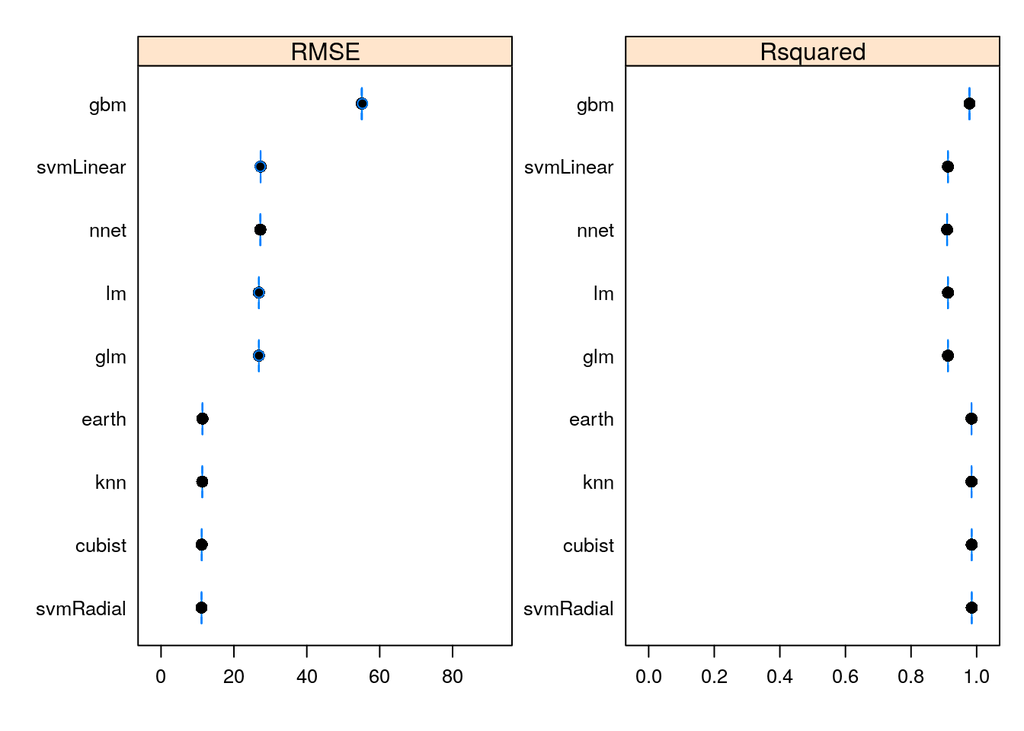

```r
bwplot(results,scales=list(relation="free"),xlim=list(c(0,90),c(0,1)))
```

```r
modelDifferences<-diff(results)
print(modelDifferences)
```

```
##
## Call:
## diff.resamples(x = results)
##
## Models: lm, glm, svmRadial, svmLinear, cubist, knn, earth, gbm, nnet
## Metrics: RMSE, Rsquared
## Number of differences: 36
## p-value adjustment: bonferroni
```

## Predictions

```r
lm.predict        <- raster::predict(m1.lm, newdata = test)
glm.predict       <- raster::predict(m2.glm, newdata = test)
svmRadial.predict <- raster::predict(m4.svmRadial, newdata = test)
svmLinear.predict <- raster::predict(m5.svmLinear, newdata = test)
cubist.predict    <- raster::predict(m7.cubist, newdata = test)
knn.predict       <- raster::predict(m9.knn, newdata = test)
earth.predict     <- raster::predict(m10.earth, newdata = test)
gbm.predict       <- raster::predict(m11.gbm, newdata = test)
#fuzzy.predict     <- raster::predict(m12.fuzzy, newdata = test)
nnet.predict      <- raster::predict(m13.nnet, newdata = test)
```

## Model evaluation

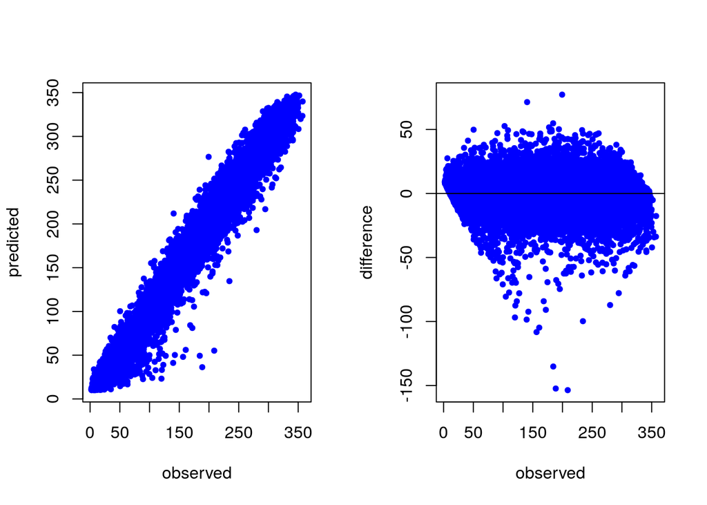

```r
#svmRadial
svmRadial.diff<-svmRadial.predict-test$Q

par(mfrow=c(1,2))
plot(test$Q,svmRadial.predict,type="p",col="blue",pch=20,xlab="observed",ylab="predicted")
plot(test$Q,svmRadial.diff,type="p",col="blue",pch=20,xlab="observed",ylab="difference")
abline(0,0)
mtext("svmRadial", outer = TRUE, cex = 1.5)
```

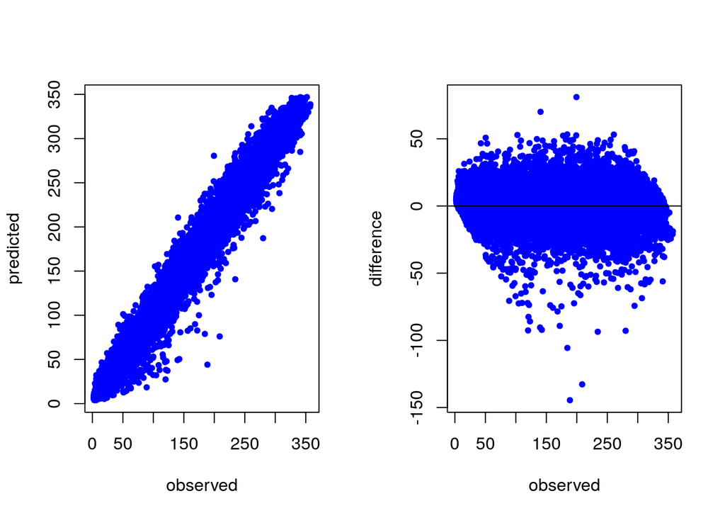

```r
#knn
knn.diff<-knn.predict-test$Q

par(mfrow=c(1,2))
plot(test$Q,knn.predict,type="p",col="blue",pch=20,xlab="observed",ylab="predicted")
plot(test$Q,knn.diff,type="p",col="blue",pch=20,xlab="observed",ylab="difference")
abline(0,0)
mtext("knn", outer = TRUE, cex = 1.5)
```

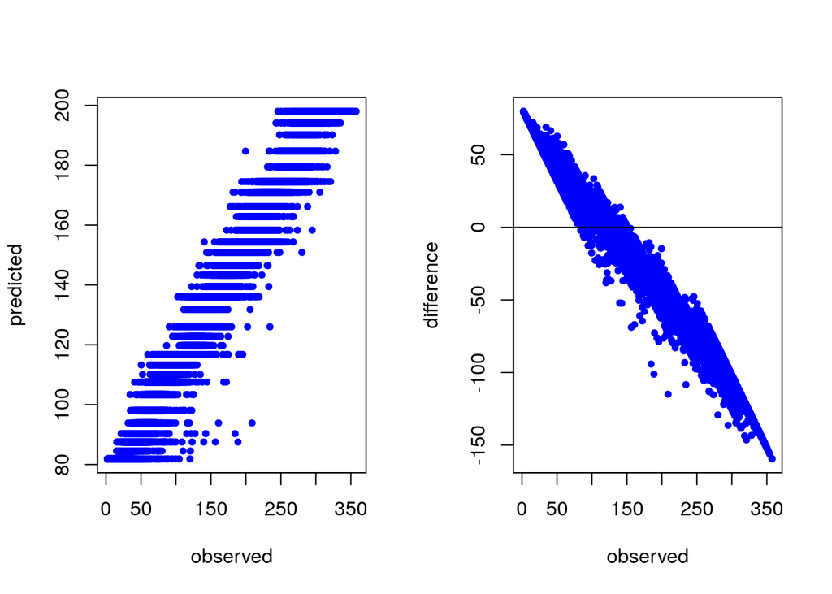

```r
#gbm
gbm.diff<-gbm.predict-test$Q

par(mfrow=c(1,2))
plot(test$Q,gbm.predict,type="p",col="blue",pch=20,xlab="observed",ylab="predicted")
plot(test$Q,gbm.diff,type="p",col="blue",pch=20,xlab="observed",ylab="difference")
abline(0,0)
mtext("gbm", outer = TRUE, cex = 1.5)
```

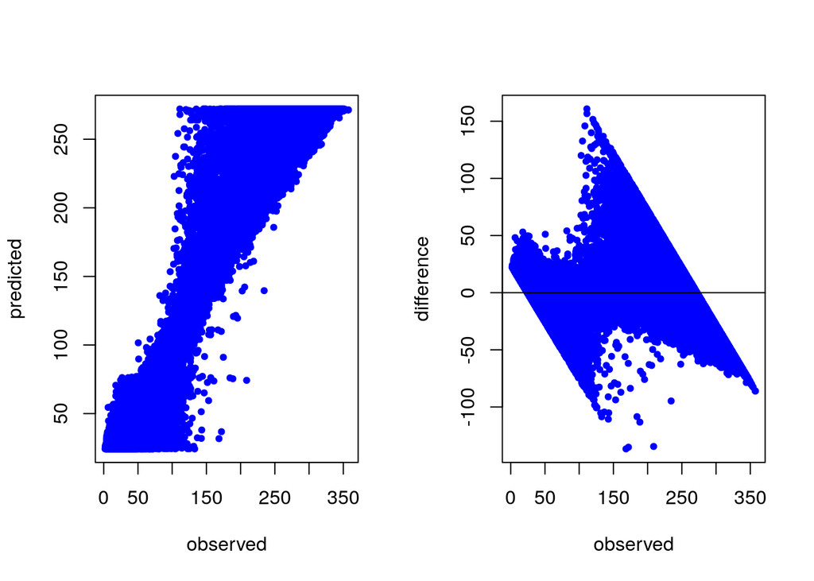

```r
#nnet
nnet.diff<-nnet.predict-test$Q

par(mfrow=c(1,2))
plot(test$Q,nnet.predict,type="p",col="blue",pch=20,xlab="observed",ylab="predicted")
plot(test$Q,nnet.diff,type="p",col="blue",pch=20,xlab="observed",ylab="difference")
abline(0,0)
mtext("nnet", outer = TRUE, cex = 1.5)
```